# QML tutorial - Week 5

### 5.1 Log-transformation

But we have a trick in our pocket: just calculate the **logarithm** of the values and they will conform to a Gaussian distribution! This is a common trick in psycholinguistics for modelling reaction time data. You can calculate the logarithm (or log) of a number in R using the `log()` function. Calculating the logs of a variable is known as a **log-transformation**.

I will illustrate what this looks like with the first five values of `RT` in `shallow`.

```r
RT <- c(603, 739, 370, 821, 1035)
RT
```

```
[1]  603  739  370  821 1035
```

```r
log(RT)
```

```
[1] 6.401917 6.605298 5.913503 6.710523 6.942157
```

So the log of 603 is `6.4`, the log of `739` is `6.6` and so on.

The `shallow` data table already has a column with the log-transformed RTs: `logRT`. So let’s plot that now.

```
Warning: Removed 4 rows containing non-finite values (`stat_density()`).
```

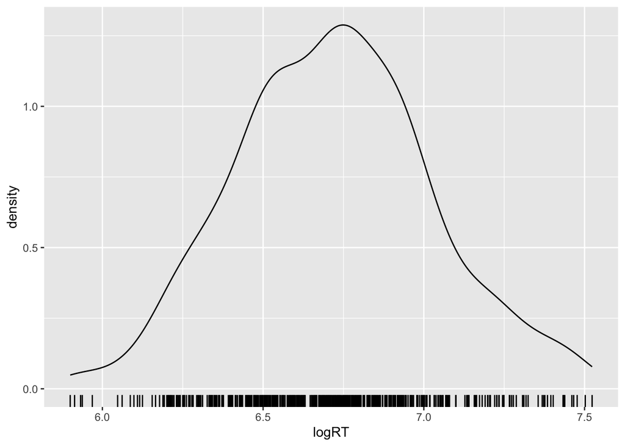

```r
shallow %>%
  ggplot(aes(logRT)) +
  geom_density() +
  geom_rug()
```

**Warning**: it is usually not possible to rely on the shape of the probability density to determine if the probability is Gaussian or not! Rather, ask yourself the following question: are the values bounded to positive numbers only? If the answer is “yes”, then the variable is **not** Gaussian and you know you can log-transform it.

**Log-normal distribution**

Variables that are Gaussian (normal) when they are log-transformed follow the **log-normal** distribution.

Now let’s look at a violin and strip plot with `Relation_type` on the *x*-axis and `logRT` on the *y*-axis.

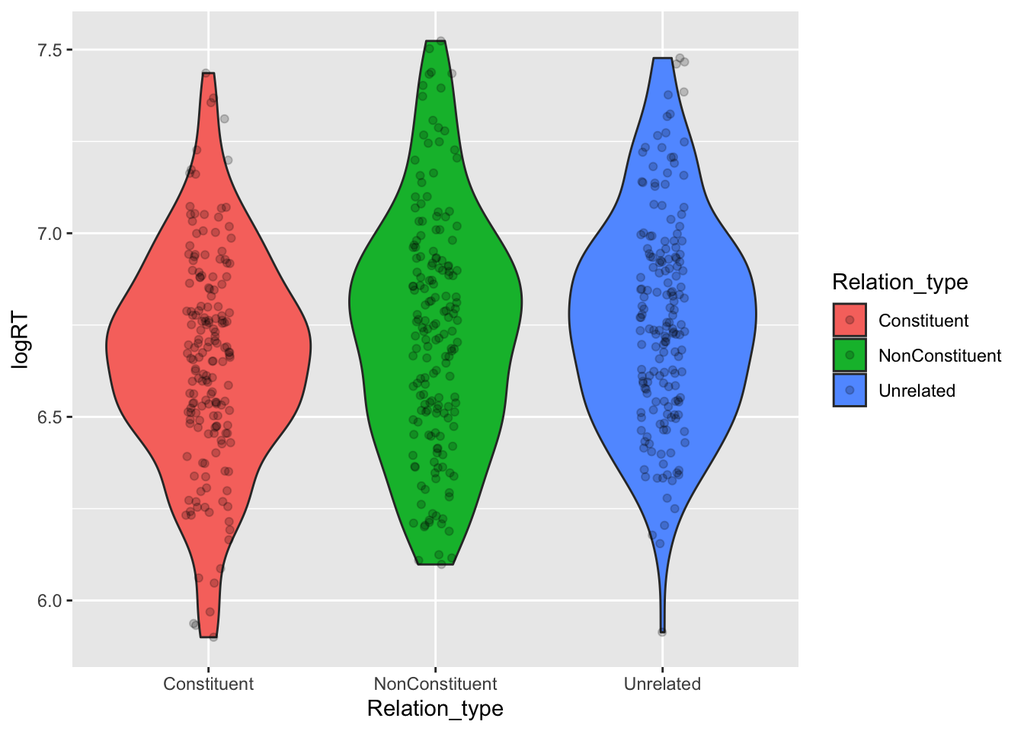

```r
shallow %>%
  ggplot(aes(Relation_type, logRT, fill = Relation_type)) +
  geom_violin() +
  geom_jitter(width = 0.1, alpha = 0.2)
```

Based on this, we can see that the bulk of the distribution (the place where the violin is wider) falls somewhat lower on the log-RT scale for the `Constituent` condition relative to the other conditions.

### 5.2 Ordering levels of a categorical predictor

By default, the levels in `Relation_type` follow the order: Constituent, NonConstituent, Unrelated (this is the default alphabetical order).

There is nothing bad with this *per se*, but maybe we can reorder them so that they are in this order: Unrelated, NonConstituent, Constituent.

This might make a bit more sense from a conceptual point of view (you can think of the unrelated condition as the “baseline” condition).

To order levels in R, we can use a **factor** variable/column.

```r
shallow <- shallow %>%
  mutate(
    Relation_type = factor(Relation_type, levels = c("Unrelated", "NonConstituent", "Constituent"))
  )
```

This overwrites the `Relation_type` column so that the levels are in the specified order. You can check this in the Environment tab: click on the blue arrow next to `shallow` to see the column list and now `Relation_type` is a `Factor` column with 3 levels.

### 5.3 Model RTs by relation type

Now it’s your turn! With the following guidance, go ahead and run a model with `brm()` to investigate the effect of relation type on log-RT. Inspect the model summary and plot the posterior probabilities.

`Relation_type` is a categorical variable with three levels, so here’s what treatment coding looks like (there will be N-1 = 3-1 = 2 dummy variables).

|  | relation_ncons | relation_cons |
| --- | --- | --- |
| relation = unrelated | 0 | 0 |
| relation = non-constituent | 1 | 0 |
| relation = constituent | 0 | 1 |

Here are a few formulae that describe in mathematical notation the model that we’ll need to fit. Try to go through them and unpack them based on what you’ve learned above and in the lecture.

$$\begin{aligned}
\text{logRT} &\sim Gaussian(\mu, \sigma) \\
\mu &= \beta_0 + \beta_1 \cdot relation_{ncons} + \beta_2 \cdot relation_{cons} \\
\beta_0 &\sim Gaussian(\mu_0, \sigma_0)\\
\beta_1 &\sim Gaussian(\mu_1, \sigma_1)\\
\beta_2 &\sim Gaussian(\mu_2, \sigma_2)\\
\sigma &\sim TruncGaussian(\mu_3, \sigma_3)
\end{aligned}$$

Focus especially on $\beta_0$, $\beta_1$ and $\beta_2$. What do they correspond to?

Fit the model with `brm()`. What does the R formula for this model look like?

Check the model summary. What can you say based on the estimates and the CrIs?

Plot the *posterior probability distributions* of $\beta_0$, $\beta_1$ and $\beta_2$ and the *conditional probability distributions* of mean log-RTs for each relation type.

A hint for the conditional probability distributions: to plot these you need to *sum* the posterior draws of the beta coefficients depending on the level of relation type. Use the formula of $\mu$ to guide you: the process is the same as with the emotional valence data above, but now there are 3 levels instead of two.

## 6 Summary

**Treatment coding**

- Categorical predictors need to be coded as numbers.
- N-1 **dummy variables**, where N is number of levels in the predictor.
- Level ordering is *alphabetical* but you can specify your own.
- **NOTE**: you don’t have to apply treatment coding yourself! It’s done under the hood by R.

**Interpreting coefficients**

- The **Intercept** $\beta_0$ is the mean of the reference level.
- The other $\beta$’s are the **difference** of the other levels relative to the reference level.

**Conditional posterior probability distributions**

- To calculate the conditional posterior probability distributions (conditional probabilities for short) you need to extract the **draws** of the model with `as_draws_df()`.

**Log-normal distribution**

- Continuous variables that are Gaussian when transformed to logs follow the **log-normal** distribution.
- You can fit a Gaussian model to log-transformed values if the variable is log-normal.

## Footnotes

[^1]: Note that, in real-life research contexts, you should decide which distribution to use for different outcome variables by drawing on previous research that has assessed the possible distribution families for those variables, on domain-specific expertise or common-sense. You will see that in most cases with linguistic phenomena we know very little about the nature of the variables we work with, hence it can be difficult to know which family of distributions to use.
[^2]: The following code is a bit of a hack. There is a better way to do this using `pivot_longer()` from the [tidyr](https://tidyr.tidyverse.org) package. We will learn how to use this and other functions from that package later in the course.
[^3]: In fact, we have assumed above that emotional valence is distributed according to a Gaussian distribution, and we got lucky that this assumption in principle holds for the values in the data sample, because emotional valence as measured in the study is actually bounded between 1 and 8. In most cases you won’t be lucky, so always carefully think about the nature of your variables. Again, only conceptual theories of the phenomena you are investigating will be able to help.